# Effects of Borrower Characteristics on Loan Amount and Rates

## Investigation Overview

In this investigation, I want to look at the characteristics of a borrower that could be key deciding factors into the Loan amount they may be eligible to get and the interest rate they could attract.

## Dataset Overview

The dataset consist of information regarding 113,937 loans dispersed by the prosper loan company, including features like loan term, duration, amount, creditscore, borrower rate, etc

## Distribution of Loan Amount

The distribution takes on a very wide range from 1000 t0 35000. It congests at the left and becomes scarce down the right. However, there are spikes at intervals of 5000 (e.g. 5000, 10000, 15000, 20000, 25000)

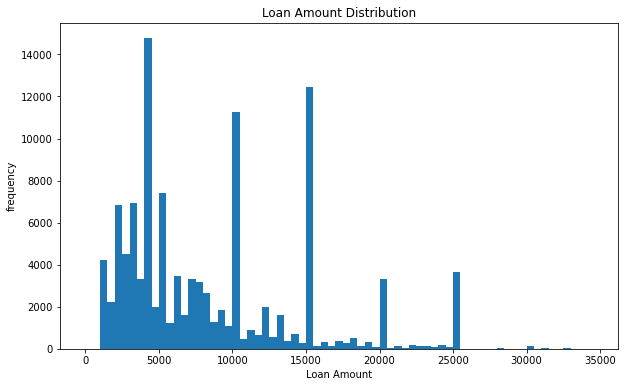

## Distribution of Borrower Rate

Both `BorrowerRate` and `BorrowerAPR` initially appear to ba a normal distribution until a sudden spike in frequency is observed at about 0.32 for the formeer and 0.36 for the latter.

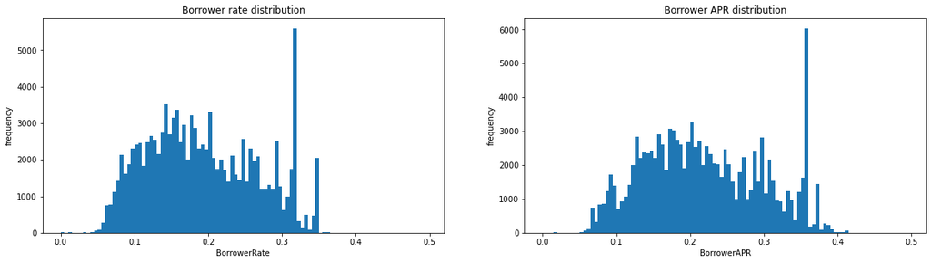

## Home Ownership Status vs. Loan Amount

The violin plot reveals something interesting - Borrowers without homes get the bulk of the loan for loan amounts around the 5000 (lower loan amounts) mark. Things seem evenly matched at the 10000 mark but as we proceed higher up the scale, just above the 10000 mark we see that most of the loans given is designated to borrowers with homes (observe the 15000, 20000, 25000 marks. there's even a little bump at the 35000 mark for the borrower with home category). The box plot shows the median for the distribution of borrowers without homes is much lower than that for borrowers with homes, suggesting a more uniform distribution in the latter than in the former.

in other words, the distribution for borrowers without homes is more congested at the lower part of the scale and very much skewed higher up the scale while the distribution for borrowers with homes is relatively more evenly distributed atleast when compared to the former, although still a little bit skewed higher up the scale.

One could say borrowers with homes are more eligible for higher loan amounts.

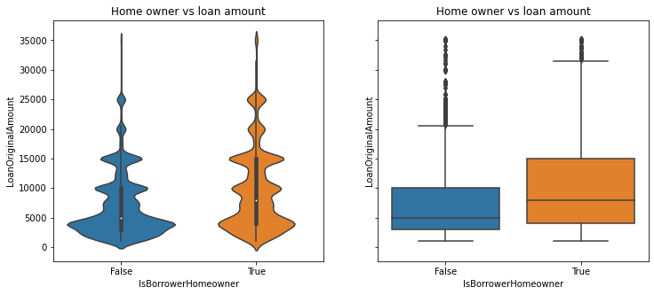

## Prosper Rating against Loan Amount by Home Ownership Status

Our observation is hence valid. Homeowners will generally be more eligible for higher loans than non-homeowners. This observation especially stands with borrower of rating 4 (C) or higher.

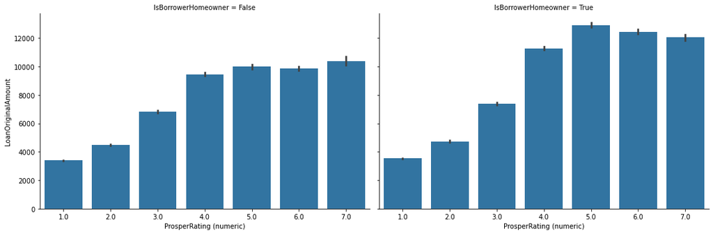

## Prosper/Credit Score vs. Loan Original Amount

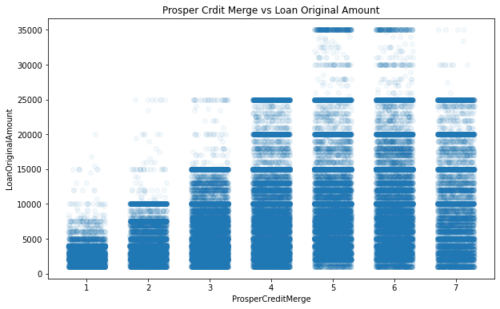

## Prosper/Credit Rating vs. Borrower Rate

The violin plot shows clearly that borrowers with higher Prospr/Credit rating generally get more favourable terms on loans as is expected.

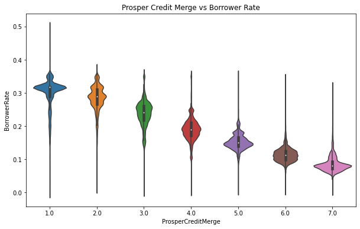

## LoanOriginalAmount by BorrowerRate and Prosper/Credit Score

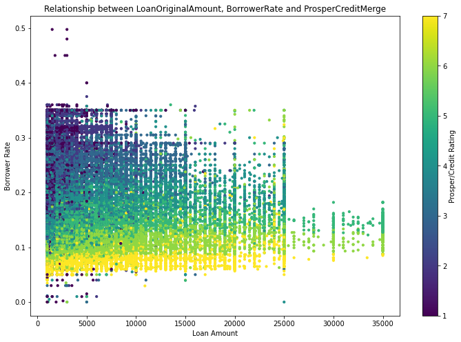

## LoanOriginalAmount by BorrowerRate with Prosper/Credit Score and Pre/Post 2009

We observe from this plot that the borrower `Rating` became a stronger deciding factor for the `BorrowerRate` after July 2009 as opposed to before this date. Also, after July 2009, the more money a person borrows the lesser the rate they are likely to get. This was not necessarily the case before July 2009.

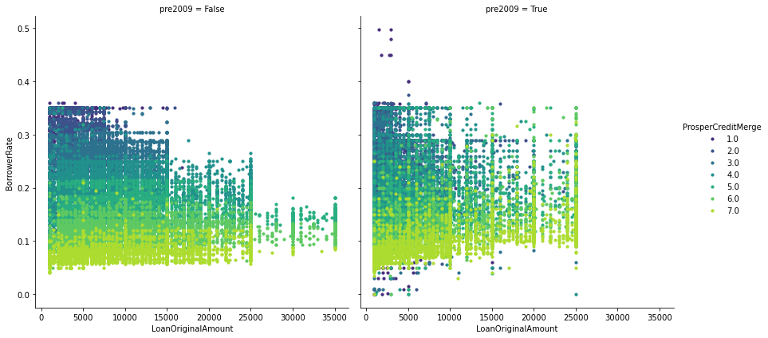

```
^C
```